# DSA2101 Group Project: World Cup Dataset

Chia Kwang Yang

Lee Weng Heng, Jon

Qiu Zi Hao

Tan Teck Hwe Damaen

Valerie Oh (Hu Xue Yong)

2023-11-17

# Introduction

The FIFA World Cup Dataset covers every single World Cup match played in its history from Uruguay in 1930 to Russia in 2018. The dataset consists of two `csv` files: `wcmatches.csv` and `worldcups.csv`.

1. The `wcmatches.csv` file contains every football match played in the World Cup, with some columns like which year, which team claimed victory, and what the win condition was.
2. The `worldcups.csv` file contains the winners and has some dataset features like winners, games, goals_scored and more.

We load the libraries to be used here:

```r
library(tidytuesdayR)
library(readr)
library(tidyverse)
library(stringr)
library(forcats)
library(maps)
library(ggthemes)
library(ggrepel)
```

# Data Cleaning and Summary

```r
tuesdata <- tidytuesdayR::tt_load('2022-11-29')
wcmatches <- tuesdata$wcmatches
worldcups <- tuesdata$worldcups
```

## Data Cleaning

```r
# Code block for the worldcups dataset

# Transform the 'worldcups' data frame using pivot_longer
worldcups_tidy <- worldcups %>%
  pivot_longer(winner:fourth, names_to = "position_status", values_to = "country_name") %>%

  # Rename columns for clarity
  rename(host_country = host) %>%

  # Standardize country names for the host and participating countries
  mutate(
    host_country = ifelse(host_country == "USA", "United States", host_country),
    country_name = ifelse(country_name == "USA", "United States", country_name)
  )
```

For the `wcmatches` dataset, we refined column names from `stage` to `stage_status` and `outcome` to `win_outcome`. We realised that `stage_status` did not have consistent values amongst the Group Stage and Finals, and converted `Group` to `Group Stage` and `Final Round` to `Final` for consistency. We removed the `date` column, and cleaned up the columns denoting the wins by expanding the `win_outcome` column to represent Home, Draw and Away and filled missing values in `win_conditions` with `Nil`. Lastly, we featured engineer the score difference as well as the win conditions, creating two new features `after_extra_time` and `penalties`. Additionally, some former teams like the Soviet Union and Yugoslavia were renamed to their present-day countries in preparation for our heatmap using `map_data("world")` from the `maps` package.

```r
# Code block for the wcmatches dataset

country_replacer <- function(x) {case_when(
      x %in% c("West Germany", "East Germany") ~ "Germany",
      x %in% c("Soviet Union") ~ "Russia",
      x %in% c("Yugoslavia", "FR Yugoslavia") ~ "Serbia",
      x %in% c("Czechoslovakia") ~ "Czech Republic",
      x %in% c("Dutch West Indies") ~ "Indonesia",
      x %in% c("Zaire") ~ "Democratic Republic of the Congo",
      TRUE ~ x)}

# Rename columns for clarity
wcmatches_tidy <- wcmatches %>%
  rename(stage_status = stage, win_outcome = outcome) %>%
  # Standardize values in the 'stage_status' column
  mutate(
    stage_status = ifelse(str_detect(stage_status, "Group"), "Group Stage", stage_status),
    stage_status = ifelse(stage_status == "Final Round", "Final", stage_status)
  ) %>%
  # Remove the 'date' column
  select(-date) %>%
  mutate(
    # Categorize win outcomes for clear representation
    win_outcome = case_when(
      home_score == away_score ~ "Draw",
      win_outcome == "H" ~ "Home",
      win_outcome == "D" ~ "Draw",
      win_outcome == "A" ~ "Away"
    ),
    # Clean countries up
    country = country_replacer(country),
    winning_team = country_replacer(winning_team),
    home_team = country_replacer(home_team),
    away_team = country_replacer(away_team)

  ) %>%

  # Feature engineering
  mutate(
    # Calculate score difference
    score_difference = abs(home_score - away_score),

    # Handle missing win conditions
    win_conditions = replace_na(win_conditions, "Nil"),

    # Create binary features based on win conditions
    after_extra_time = ifelse(str_detect(win_conditions, "AET"), 1, 0),
    penalties = ifelse(str_detect(win_conditions, "penalties"), 1, 0)
  )

wcmatches_tidy %>% filter(country == "Germany")
```

```
## # A tibble: 102 × 17
##     year country city     stage_status home_team away_team home_score away_score
##    <dbl> <chr>   <chr>    <chr>        <chr>     <chr>          <dbl>      <dbl>
##  1  1974 Germany Frankfu… Group Stage  Brazil    Serbia             0          0
##  2  1974 Germany Dortmund Group Stage  Democrat… Scotland           0          2
##  3  1974 Germany Hamburg  Group Stage  Germany   Australia          2          0
##  4  1974 Germany Berlin   Group Stage  Germany   Chile              1          0
##  5  1974 Germany Munich   Group Stage  Italy     Haiti              3          1
##  6  1974 Germany Stuttga… Group Stage  Poland    Argentina          3          2
##  7  1974 Germany Düsseld… Group Stage  Sweden    Bulgaria           0          0
##  8  1974 Germany Hanover  Group Stage  Uruguay   Netherla…          0          2
##  9  1974 Germany Berlin   Group Stage  Chile     Germany            1          1
## 10  1974 Germany Hamburg  Group Stage  Germany   Australia          3          0
## # ℹ 92 more rows
## # ℹ 9 more variables: win_outcome <chr>, win_conditions <chr>,
## #   winning_team <chr>, losing_team <chr>, month <chr>, dayofweek <chr>,
## #   score_difference <dbl>, after_extra_time <dbl>, penalties <dbl>
```

```r
worldcups_tidy
```

```
## # A tibble: 84 × 8
##     year host_country goals_scored teams games attendance position_status
##    <dbl> <chr>               <dbl> <dbl> <dbl>      <dbl> <chr>
##  1  1930 Uruguay                70    13    18     434000 winner
##  2  1930 Uruguay                70    13    18     434000 second
##  3  1930 Uruguay                70    13    18     434000 third
##  4  1930 Uruguay                70    13    18     434000 fourth
##  5  1934 Italy                  70    16    17     395000 winner
##  6  1934 Italy                  70    16    17     395000 second
##  7  1934 Italy                  70    16    17     395000 third
##  8  1934 Italy                  70    16    17     395000 fourth
##  9  1938 France                 84    15    18     483000 winner
## 10  1938 France                 84    15    18     483000 second
## # ℹ 74 more rows
## # ℹ 1 more variable: country_name <chr>
```

There are a few interesting statistics that we have found out with the datasets:

1. The years 1942 and 1946 are not included in the dataset. Upon further research, we realise that the World Cup was not held in 1942 and 1946 due to the Second World War (Marcotti, 2014). This leads to a larger year difference of 12 years between the 1938 and the 1950 World Cup matches, which will be reflected in some of our plots.
2. The years 1934, 1938 and 1950 had a very different format, unlike traditional World Cups (Topend Sports, n.d.). A traditional World Cup often consists of the Group Stages, Round of 16, Quarterfinals, Semifinals and Finals. Typically, matches after the group stages were played in a knockout format, i.e. the winning team will continue, while the losing team was eliminated. However, in 1934 and 1938, there were no group stages, while in 1950, the stages after the group stages were considered “Finals” and played just like group stages instead of the aforementioned knockout format. This will be reflected in some of our plots as well.

```r
# The years where the World Cup is supposed to be held on
supposed_years <- seq(1930, 2018, by = 4)

# The years where the World Cup is actually held on, for visualization purposes
actual_years <- wcmatches_tidy %>%
  select(year) %>%
  distinct()

# Find years that do not exist in actual_years
missing_years <- supposed_years[!(supposed_years %in% actual_years$year)]
missing_years
```

```
## [1] 1942 1946
```

```r
# Stages for 1934
stages_1934 <- wcmatches_tidy %>%
  filter(year == 1934) %>%
  select(stage_status) %>%
  distinct()

# Stages for 1938
stages_1938 <- wcmatches_tidy %>%
  filter(year == 1938) %>%
  select(stage_status) %>%
  distinct()

stages_1950 <- wcmatches_tidy %>%
  filter(year == 1950) %>%
  select(stage_status) %>%
  distinct()

stages_1934
```

```
## # A tibble: 5 × 1
##   stage_status
##   <chr>
## 1 Round of 16
## 2 Quarterfinals
## 3 Semifinals
## 4 Third place
## 5 Final
```

```r
stages_1938
```

```
## # A tibble: 5 × 1
##   stage_status
##   <chr>
## 1 Round of 16
## 2 Quarterfinals
## 3 Semifinals
## 4 Third place
## 5 Final
```

```r
stages_1950
```

```
## # A tibble: 2 × 1
##   stage_status
##   <chr>
## 1 Group Stage
## 2 Final
```

Lastly, here are some descriptive statistics that will help understand some of these plots better:

```r
# Total number of World Cups
total_world_cups <- wcmatches_tidy %>%
  distinct(year) %>%
  summarize(total_world_cups = n())

# Total games played so far
total_games_played <- worldcups_tidy %>%
  select(games) %>%
  summarize(total_games_played = sum(games))

# Number of teams that have participated throughout the world cup
total_teams_participated <- wcmatches_tidy %>%
  select(home_team) %>%
  distinct() %>%
  rename(country = home_team) %>%
  bind_rows(wcmatches_tidy %>%
              select(away_team) %>%
              distinct() %>%
              rename(country = away_team)) %>%
  distinct() %>%
  summarize(total_teams_participated = n())

# Number of max goals scored by a host
max_goals_home <- wcmatches_tidy %>%
  select(home_score) %>%
  summarize(max_goals_home = max(home_score))

# Biggest difference between two countries
max_difference <- wcmatches_tidy %>%
  select(score_difference) %>%
  summarize(max_difference = max(score_difference))

descriptive_statistics <- bind_cols(total_world_cups, total_games_played, total_teams_participated, max_goals_home, max_difference)

descriptive_statistics
```

```
## # A tibble: 1 × 5
##   total_world_cups total_games_played total_teams_participated max_goals_home
##              <int>              <dbl>                    <int>          <dbl>
## 1               21               3600                       78             10
## # ℹ 1 more variable: max_difference <dbl>
```

These are all in preparation to answer the question: **What factors affect the performance of the World Cup?**

# Visualisations

To answer our question, we prepared three visualisations: a heatmap, a scatterplot and a line plot.

## Visualisation 1: Heatmap

We want to see if geographical factors affect the performance of the World Cup. Therefore, we manipulated the data to tabulate the all-time total points for each country, before showcasing the total points across all World Cup matches on a heatmap. A heatmap, in this case, is good to show intensity in data through the use of a blue colour gradient which shows the points earned throughout the World Cups. From there, we can see that South American and European countries usually dominate the World Cups, with Brazil, Germany and Italy scoring the highest points.

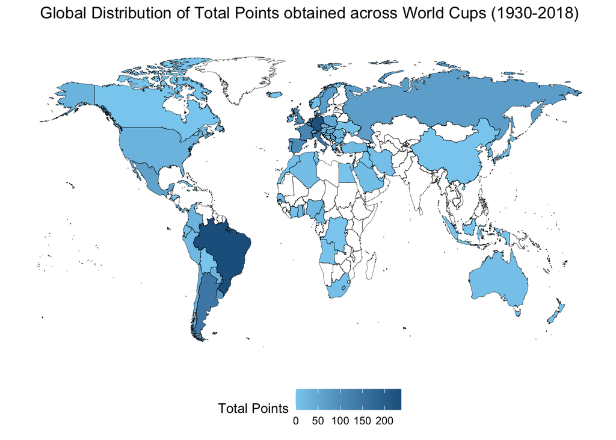

```r
# Calculate win / lose points
wcmatches_wins <- wcmatches_tidy %>%
  filter(win_outcome %in% c("Home", "Away")) %>%
  group_by(country = case_when(win_outcome == "Home" ~ home_team, win_outcome == "Away" ~ away_team)) %>%
  summarise(win_points = 3 * n())

# Calculate draw points
wcmatches_draws <- wcmatches_tidy %>%
  filter(win_outcome == "Draw") %>%
  pivot_longer(home_team:away_team) %>%
  rename(country_draw = value) %>%
  select(country_draw) %>%
  group_by(country_draw) %>%
  summarise(draw_points = n()) %>%
  rename(country = country_draw)


# Get unique home and away countries
wcmatches_allcountries <- wcmatches_tidy %>%
  select(home_team) %>%
  distinct() %>%
  rename(country = home_team) %>%
  bind_rows(wcmatches_tidy %>%
              select(away_team) %>%
              distinct() %>%
              rename(country = away_team)) %>%
  distinct()

# Tabulate the points for each country
wcmatches_tabulated <- wcmatches_wins %>%
  full_join(wcmatches_draws, by = "country") %>%
  full_join(wcmatches_allcountries, by = "country") %>%
  mutate(
    win_points = replace_na(win_points, 0),
    draw_points = replace_na(draw_points, 0),
    total_points = win_points + draw_points,
    ) %>%
  group_by(country) %>%
  summarise(total_points = sum(total_points))


# Part 2: Visualising `total_points` on a heatmap

# Consistency within regions
world_map <- map_data("world") %>%
             mutate(region = case_when(
               region == "USA" ~ "United States",
               region == "China" ~ "China PR",
               region == "Ireland" ~ "Republic of Ireland",
               subregion == "Scotland" ~ "Scotland",
               subregion == "Great Britain" ~ "England",
               subregion == "Isle of Wight" ~ "England",
               subregion == "Wales" ~ "Wales",
               subregion == "Northern Ireland" ~ "Northern Ireland",
               .default = region)) %>%
             select(-subregion)

# Join tabulated wcmatches and top countries
top_countries_joined <- wcmatches_tabulated %>%
                        full_join(world_map, by = c("country" = "region"))

ggplot(top_countries_joined, aes(x = long, y = lat, group = group)) +
  geom_polygon(aes(fill = total_points)) +
  labs(title = "Global Distribution of Total Points obtained across World Cups (1930-2018)") +
  scale_fill_continuous(name = "Total Points", low = "#89CFF0", high = "#1F618D", na.value = "white") +
  borders(colour = "black", size = 0.1) +
  theme_minimal() +
  theme(legend.position = "bottom", axis.title = element_blank(), axis.text = element_blank(),
        panel.grid = element_blank(), plot.title = element_text(hjust = 0.5)) +
  ylim(-60, 90)
```

## Visualisation 2: Scatter Plot

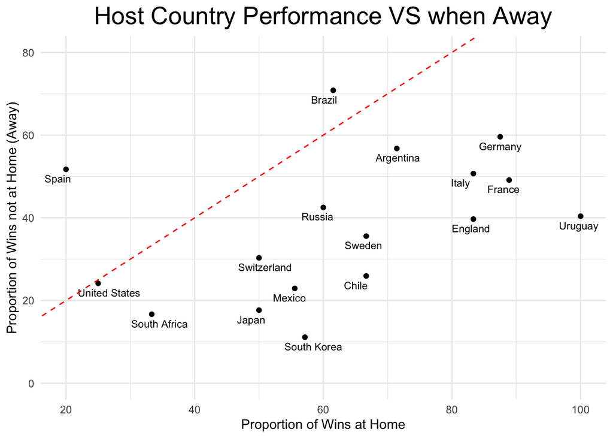

```r
# Total matches played per host country
wc_host_matches_played <- wcmatches_tidy %>%
  filter(country == home_team) %>%
  group_by(country) %>%
  summarise(total_matches_played = n())

# Total wins per host country
wcmatches_tidy1 <- wcmatches_tidy %>%
  filter(country == home_team, country == winning_team) %>%
  select(year, country, stage_status, home_team, win_outcome) %>%
  group_by(country) %>%
  summarise(host_wins = n())

# Win Proportion out of matches played
wc_host_wins_prop <- wc_host_matches_played %>%
  full_join(wcmatches_tidy1) %>%
  mutate(host_win_prop = round(host_wins * 100 / total_matches_played, 2))

# Wins when country is not host
wc_away_wins <- wcmatches_tidy %>%
  group_by(winning_team) %>%
  summarise(total_wins = n()) %>%
  rename(country = winning_team) %>%
  full_join(wcmatches_tidy1) %>%
  replace_na(list(host_wins = 0)) %>%
  mutate(away_wins = total_wins - host_wins) %>%
  select(country, away_wins)

# Matches played as 'home_team' by non-host
home_matches_played <- wcmatches_tidy %>%
  filter(country != home_team) %>%
  group_by(home_team) %>%
  summarise(home_played = n()) %>%
  rename(country = home_team)

# Matches played as 'away_team' by non-host
away_matches_played <- wcmatches_tidy %>%
  group_by(away_team) %>%
  summarise(away_played = n()) %>%
  rename(country = away_team)

#Merge all data to find proportion
wc_win_prop_combine <- home_matches_played %>%
  full_join(away_matches_played, by = 'country') %>%
  full_join(wc_away_wins, by = 'country') %>%
  replace_na(list(away_wins = 0)) %>%
  mutate(total_played = home_played + away_played) %>%
  group_by(country) %>%
  summarise(away_wins_prop = round(away_wins * 100 / total_played, 2)) %>%
  right_join(wc_host_wins_prop, by = 'country') %>%
  select(country, host_win_prop, away_wins_prop)

# Plotting
ggplot(data = wc_win_prop_combine, aes(x = host_win_prop, y = away_wins_prop)) +
  geom_point() +
  geom_text_repel(aes(label = country), hjust = -0.05, vjust = -0.05, size = 3) +
  ylim(0, 80) +
  geom_abline(color = 'red', linetype = 2) +
  labs(title = 'Host Country Performance VS when Away',
       x = "Proportion of Wins at Home",
       y = "Proportion of Wins not at Home (Away)") +
  theme_minimal() +
  theme(plot.title = element_text(hjust = 0.5, size = 20))
```

## Visualisation 3: Line Plot

Lastly, we want to find whether or not the different stages affects whether or not a country performs well in the world cup. We get the average goals for the group stages and non-group stages for each world cup and plot it using a line plot. The line plot allows us to see the changes in average goals over each world cup. Moreover, we are able to plot more than one line plot to see how the average goals change when it is during a group stage, and when it is not during a group stage. Generally, countries tend to score better during the non-group stage matches, with 73.7% of World Cups demonstrating this trend (with the exception of 1934 and 1938).

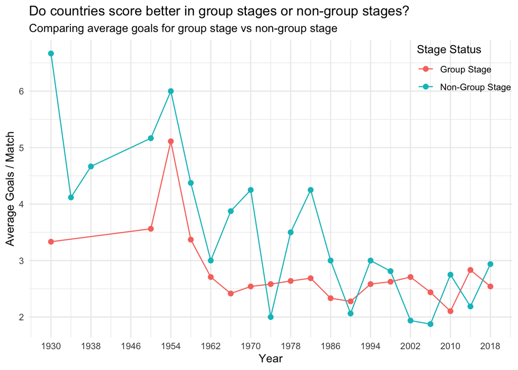

```r
viz_3_wcmatches <- wcmatches_tidy %>%
  filter(home_team == country) %>%
  select(year, home_score) %>%
  group_by(year) %>%
  summarize(total_goals_scored = sum(home_score))

viz_3_worldcups <- worldcups_tidy %>%
  rename(country = host_country) %>%
  group_by(year, country) %>%
  summarize(goals_scored = mean(goals_scored)) %>%
  select(year, country, goals_scored)
viz_3_data <- viz_3_wcmatches %>%
  left_join(viz_3_worldcups, by = "year") %>%
  mutate(goal_proportion = (total_goals_scored / goals_scored) * 100) %>%
  select(year, country, goal_proportion)

wc_goals_scored <- wcmatches_tidy  %>%
  select(year, stage_status, home_score, away_score) %>%
  mutate(total_scored = home_score + away_score) %>%
  group_by(year, stage_status) %>%
  mutate(stage_status = if_else(stage_status != 'Group Stage', 'Non-Group Stage', 'Group Stage')) %>%
  summarise(total_goals = sum(total_scored), total_matches = n()) %>%
  mutate(avg_goals_per_match = total_goals/total_matches)
ggplot(data=wc_goals_scored, aes(x=year, y=avg_goals_per_match, group = stage_status, color = stage_status)) +
  geom_line() +
  labs(title = "Do countries score better in group stages or non-group stages?",
       subtitle = "Comparing average goals for group stage vs non-group stage",
       x = "Year",
       y = "Average Goals / Match",
       color = "Stage Status") +
  geom_point(size = 2) +
  scale_x_continuous(breaks = seq(1930, 2018, by = 8)) +
  theme_minimal() +
  theme(legend.position = c(0.9, 0.9))
```

# Discussion

The primary insights we aim to convey through our visualisations are the different factors that might affect nations’ World Cup performances. Most of the visualisations appear as such because of the nature of the World Cup - it eliminates the weaker nations early during the Group Stages and the stronger nations compete against each other to earn the biggest honor for a country’s football team, explaining the heat map of total points. As the World Cup progresses, the matches get more intense as nations are one step closer to the ultimate trophy, and explains why countries score better during non-group stages.

# References

R for Data Science Community. (2022, November 29). TidyTuesday Week 48, 2022. GitHub. https://github.com/rfordatascience/tidytuesday/blob/master/data/2022/2022-11-29

Marcotti, G. (2014, May 30). 1950 World Cup unlike any other. ESPN.Com. https://www.espn.com/soccer/story/_/id/37364595/a-tournament-unlike-other

FIFA World Cup Formats. (n.d.). Topend Sports. Retrieved 17 November 2023, from https://www.topendsports.com/events/worldcupsoccer/formats.htm

USA ’94: A World Cup of firsts. (2016, May 4). FIFA Museum. https://www.fifamuseum.com/en/blog-stories/blog/usa-94-a-15th-world-cup-full-of-firsts-2610677/

Lopez, G. (2022, December 13). The power of history. The New York Times. https://www.nytimes.com/2022/12/13/briefing/morocco-world-cup.html